# SES and LES

Jiantong Wang

## Simple Exponential Smoothing

#### WFJ Example

In this example, we need load in the dataset of WFJ sales.

```r
WFJ_Full <- read.csv("WFJ_Sales_Full.csv")
WFJ_Full.ts <- ts(WFJ_Full$WFJ.Sales,start = 1,frequency = 1)
```

The only parameter we need for SES is $\aplha$. The parameter can be user specified, or generated by R. Here for example, we want to make SES with alpha = 0.2, 0.5, and 0.7.

```r
alpha_set <- c(0.2, 0.5, 0.7)
alpha_set
```

```
## [1] 0.2 0.5 0.7
```

Then let’s create a new matrix to store SES forecasts.

```r
WFJ.frc.SES <- matrix(NA, nrow = 62, ncol = 3)
colnames(WFJ.frc.SES) <- paste("alpha=", alpha_set)
head(WFJ.frc.SES)
```

```
##      alpha= 0.2 alpha= 0.5 alpha= 0.7
## [1,]         NA         NA         NA
## [2,]         NA         NA         NA
## [3,]         NA         NA         NA
## [4,]         NA         NA         NA
## [5,]         NA         NA         NA
## [6,]         NA         NA         NA
```

**Use the iteration to calculate the predicted values**

Let’s recall the formula from our lecture:

$$F_{t+1}=L_{t+1}=(1-a) L_t+a y_t=L_t+a e_t$$

So, for each time, to calculate the prediction, all we need are last time period’s prediction error and smoothing parameter.

```r
WFJ.frc.SES_iter <- WFJ.frc.SES
for(i in 2:62){
  if(i == 2) {
    predicted <- WFJ_Full.ts[1]
    WFJ.frc.SES_iter[2,] <- rep(predicted,3)
  }else{
    for(k in 1:3){
      alpha <- alpha_set[k]
      error <- WFJ_Full.ts[(i-1)] - WFJ.frc.SES_iter[(i-1),k]
      predicted <- WFJ.frc.SES_iter[(i-1),k] + alpha * error
      WFJ.frc.SES_iter[i,k] <- predicted
    }
  }
}
head(WFJ.frc.SES_iter)
```

```
##      alpha= 0.2 alpha= 0.5 alpha= 0.7
## [1,]         NA         NA         NA
## [2,]   23056.13   23056.13   23056.13
## [3,]   23408.37   23936.72   24288.96
## [4,]   23586.60   24118.14   24296.37
## [5,]   23517.78   23680.30   23558.64
## [6,]   23386.68   23271.30   23071.20
```

**use ets() function**

ets() function is used to fit exponential smoothing state space model. We will discuss this kind of models later this semester.

```r
library(forecast)
for (i in 2:62){
  k <- i
  ts.ref <- WFJ_Full.ts[1:(k-1)]
  for (j in 1:3){ # we have 3 alphas
    fit.model <- ets(ts.ref,model="ANN",alpha=alpha_set[j])
    # in model part, the first letter A stands for our error term is additive, which means the random error is additive the prediction.
    # the second letter denotes trend. For here, we do not have trend in our model, so it is N: None
    # the third letter denotes season. For here, we do not have seasonal pattern in our model, so it's N.
    WFJ.frc.SES[i,j] <- forecast::forecast(fit.model,h=1)$mean
  }
}
head(WFJ.frc.SES)
```

```
##      alpha= 0.2 alpha= 0.5 alpha= 0.7
## [1,]         NA         NA         NA
## [2,]   23056.13   23056.13   23056.13
## [3,]   23408.37   23936.72   24288.96
## [4,]   23586.60   24118.14   24296.37
## [5,]   23517.78   23680.30   23558.64
## [6,]   23386.68   23271.30   23071.20
```

**Make time series plot**

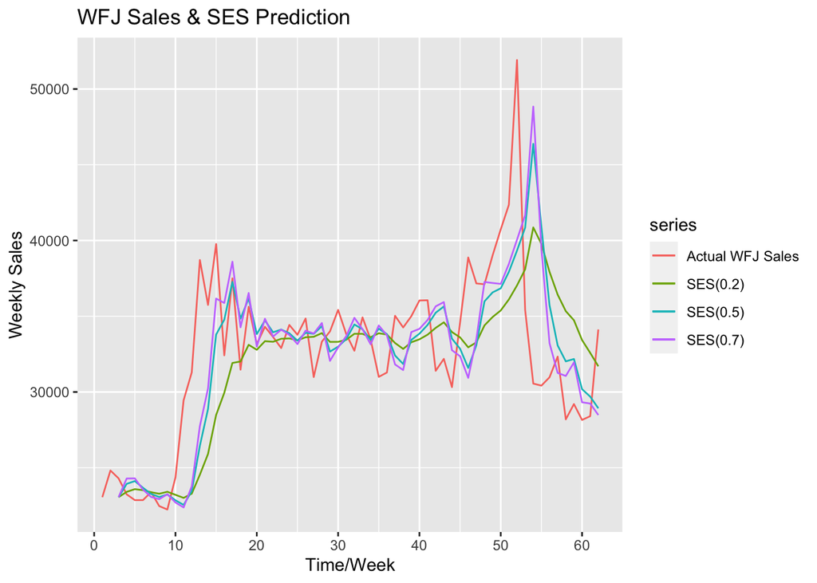

```r
WFJ_SES_0.2.ts <- ts(WFJ.frc.SES[,1],start = 2,end = 62,frequency = 1)
WFJ_SES_0.5.ts <- ts(WFJ.frc.SES[,2],start = 2,end = 62,frequency = 1)
WFJ_SES_0.7.ts <- ts(WFJ.frc.SES[,3],start = 2,end = 62,frequency = 1)

autoplot(WFJ_Full.ts,ylab="Weekly Sales", main = "WFJ Sales & SES Prediction",xlab = "Time/Week", series = "Actual WFJ Sales") +
  autolayer(WFJ_SES_0.2.ts, col = 2, series = "SES(0.2)") +
  autolayer(WFJ_SES_0.5.ts, col = 3, series = "SES(0.5)") +
  autolayer(WFJ_SES_0.7.ts, col = 3, series = "SES(0.7)")
```

**Compare the performance of each alpha**

We can calculate the RMSE of the 3 models.

```r
error_SES_0.2 <- WFJ_Full.ts - WFJ_SES_0.2.ts
error_SES_0.5 <- WFJ_Full.ts - WFJ_SES_0.5.ts
error_SES_0.7 <- WFJ_Full.ts - WFJ_SES_0.7.ts


RMSE_SES_0.2 <- sqrt(mean(error_SES_0.2^2, na.rm = T))
RMSE_SES_0.5 <- sqrt(mean(error_SES_0.5^2, na.rm = T))
RMSE_SES_0.7 <- sqrt(mean(error_SES_0.7^2, na.rm = T))

c(RMSE_SES_0.2, RMSE_SES_0.5, RMSE_SES_0.7)
```

```
## [1] 4871.759 4490.625 4424.289
```

Among 0.2, 0.5, 0.7, $\alpha = 0.7$ is the best smoothing parameter.

**Select Optimal Paramter by ets()**

```r
ets(WFJ_Full.ts,model="ANN")$par
```

```
##        alpha            l
## 7.310805e-01 2.347550e+04
```

The optimal $\alpha$ selected by ets() is 0.731.

## Linear Exponential Smoothing

**Read in data and basic visualization**

When a time series has a long-term trend, we should consider using linear exponential smoothing model. Here we have the total revenues of Netflix. First of all, let’s draw a time series plot of it.

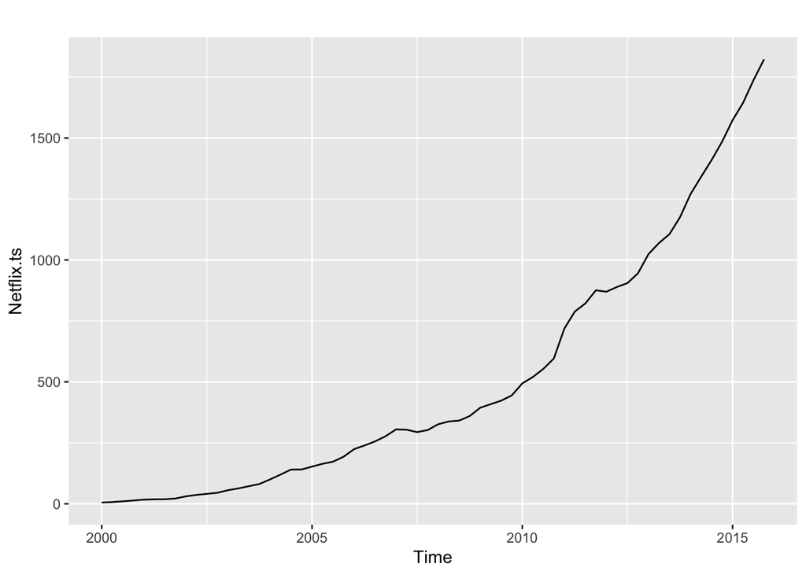

```r
Netflix <- read.csv("Netflix.csv")
Netflix.ts <- ts(Netflix$Total.Revenues,start = c(2000,1), frequency = 4)
autoplot(Netflix.ts)
```

From the time series plot, obviously, there is an increasing trend. An LES model should be adopted.

**Find optimal parameters**

We can use ets() function to help us find optimal parameters.

```r
# Find optimal alpha and beta
ets(Netflix.ts ,model="AAN")$par
```

```
##      alpha       beta          l          b
##  0.9999000  0.4420412 -0.3568988  3.7055700
```

```r
alpha_opt <- ets(Netflix.ts ,model="AAN")$par[1]
```

We can find the optimal parameters for the LES model are $\alpha = 1, \beta = 0.44$.

We can also specify $\alpha$ by ourselves. For example, we also set $\alpha$ = 0.2, 0.5, or 0.8. To find the corresponding optimal $\beta$, we can also use ets() function.

```r
alpha <- c(0.2,0.5,0.8,alpha_opt)
k <- length(alpha)
# Find optimal betas.
beta <- vector("numeric",k)

for (i in 1:k){
  pars <- ets(Netflix.ts,model="AAN",alpha=alpha[i])$par
  beta[i] <- pars[which(names(pars)=="beta")]
}
```

Next is to create a matrix to store the predictions we are going to make. We set the column names as their parameters.

```r
frc <- matrix(NA,nrow = 64,ncol = 4)
colnames(frc) <- paste("alpha=", alpha_set,"beta = ", round(beta,2))
head(frc)
```

```
##      alpha= 0.2 beta =  0.2 alpha= 0.5 beta =  0.5 alpha= 0.7 beta =  0.55
## [1,]                     NA                     NA                      NA
## [2,]                     NA                     NA                      NA
## [3,]                     NA                     NA                      NA
## [4,]                     NA                     NA                      NA
## [5,]                     NA                     NA                      NA
## [6,]                     NA                     NA                      NA
##      alpha= 0.2 beta =  0.44
## [1,]                      NA
## [2,]                      NA
## [3,]                      NA
## [4,]                      NA
## [5,]                      NA
## [6,]                      NA
```

**Use ets() to make predictions**

We have the alpha and the corresponding optimal beta, so we can build a linear exponential smoothing model by using function ets(). Please note here, we need to set the argument of model in ets() as “AAN”, which will make the function to build a LES model. For an LES model, we have the basic equation as F = L + T + E. T is standing for trend, and E is standing for random error.

```r
n <- length(Netflix.ts)

# Produce forecasts
for (i in 3:64){
  fitsample <- Netflix.ts[1:(i -1)]
  fitsample <- ts(fitsample,frequency=frequency(Netflix.ts),start=start(Netflix.ts))
  for (j in 1:k){
    # First we fit ets with the fixed alpha value and model="AAN" - we will let it optimise the initial trend
    fit <- ets(fitsample,model="AAN",alpha=alpha[j],beta=beta[j])
    # Produce the 1-step ahead forecast
    frc[i,j] <- forecast(fit,h=1)$mean
  }
}

head(frc)
```

```
##      alpha= 0.2 beta =  0.2 alpha= 0.5 beta =  0.5 alpha= 0.7 beta =  0.55
## [1,]                     NA                     NA                      NA
## [2,]                     NA                     NA                      NA
## [3,]               10.18068               8.750063                8.362294
## [4,]               12.01510              11.180453               11.935743
## [5,]               14.17947              14.552785               15.862556
## [6,]               16.75927              18.698005               20.110058
##      alpha= 0.2 beta =  0.44
## [1,]                      NA
## [2,]                      NA
## [3,]                8.633334
## [4,]               12.351960
## [5,]               16.019719
## [6,]               20.143650
```

**Compare performance**

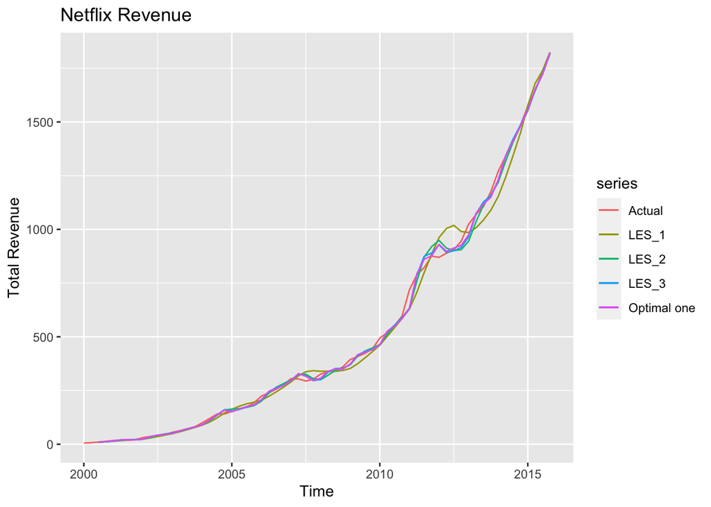

```r
LES_1 <- ts(frc[,1],start = c(2000,1),frequency = 4)
LES_2 <- ts(frc[,2],start = c(2000,1),frequency = 4)
LES_3 <- ts(frc[,3],start = c(2000,1),frequency = 4)
LES_4 <- ts(frc[,4],start = c(2000,1),frequency = 4)

autoplot(Netflix.ts,series = "Actual", main = "Netflix Revenue", ylab = "Total Revenue", xlab = "Time")+
  autolayer(LES_1) +
  autolayer(LES_2) +
  autolayer(LES_3) +
  autolayer(LES_4,series = "Optimal one")
```

```r
sqrt(mean((Netflix.ts - LES_1)^2, na.rm = T))
```

```
## [1] 42.317
```

```r
sqrt(mean((Netflix.ts - LES_2)^2, na.rm = T))
```

```
## [1] 24.92471
```

```r
sqrt(mean((Netflix.ts - LES_3)^2, na.rm = T))
```

```
## [1] 20.68453
```

```r
sqrt(mean((Netflix.ts - LES_4)^2, na.rm = T))
```

```
## [1] 19.33488
```